# BST 270 Final Project

Corriene Sept

1/19/2021

Load data:

```r
us <- read_csv("~/R/BST270-Winter2021/covid-19-data-master/us.csv")
us_states <- read_csv("~/R/BST270-Winter2021/covid-19-data-master/us-states.csv")
```

```r
national_history <- read_csv("~/R/BST270-Winter2021/national-history.csv")
```

Note that all below analyses are for **January 17, 2021.**

# 1. New cases as a function of time with a rolling average plot

First, compute new cases and new deaths on each day.

```r
us$new_cases <- us$cases - lag(us$cases)
us$new_deaths <- us$deaths - lag(us$deaths)
```

Compute 7 day average. Note that the previous 7 days are averaged (this is NOT center aligned.) The first 7 days (chronologically) in the dataset are then missing.

```r
us$new_cases_7dayavg <- rollmean(us$new_cases, k = 7, fill = NA, align = "right")
us$new_deaths_7dayavg <- rollmean(us$new_deaths, k = 7, fill = NA, align = "right")
us$deaths_7dayavg <- rollmean(us$deaths, k = 7, fill = NA, align = "right")
us$cases_7dayavg <- rollmean(us$cases, k = 7, fill = NA, align = "right")
national_history$hospitalizedCurrently_7dayavg <- rollmean(national_history$hospitalizedCurrently, k = 7, fill = NA, align = "left")
```

Create the plot: new cases as a function of time with a rolling average. The trendine is the 7-day average computed above, and the bar chart is *new cases.*

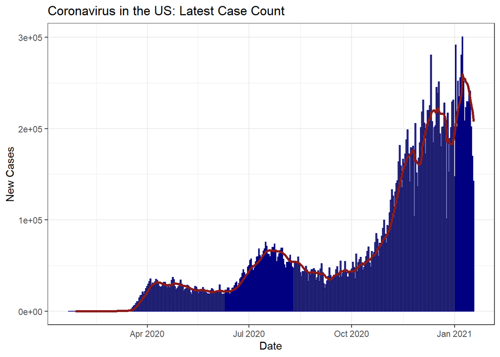

```r
p <- ggplot(us, aes(date, new_cases)) +
           geom_bar(stat="identity", na.rm = TRUE, color = "navy") +
  ggtitle("Coronavirus in the US: Latest Case Count") +
           xlab("Date") + ylab("New Cases")

p + geom_line(aes(date, new_cases_7dayavg), na.rm = TRUE, color = "firebrick4", size = 1.1) + theme_bw()
```

**Brief critique of reproducibility:**

This plot was easily reproduced using the above code. I didn’t face any issues trying to reproduce this; it was pretty self explanatory.

# 2. Table of cases, hospitalizations, and deaths

The first two columns of the table, total reported cases & deaths and Jan 17 new cases, new deaths, and currently hospitalized is already contained in the datasets us and national_history. The new cases and new deaths were computed previously. 14-day change was computed using 7-day averages for new cases, new deaths, and currently hospitalized patients. This is the percent change between the 7 day averages of new cases, new deaths, and currently hospitalized on January 3 and January 17.

Filter to January 3rd and 17th to compute the 3rd column of the table.

```r
Jan03 <- us %>%
  filter(date == "2021-01-03")
Jan17 <- us %>%
  filter(date == "2021-01-17")
```

14 day % increase: hospitalized currently 7 day average, Jan 17 and Jan 03

```r
round((national_history[2,]$hospitalizedCurrently_7dayavg - national_history[16,]$hospitalizedCurrently_7dayavg) / national_history[16,]$hospitalizedCurrently_7dayavg * 100)
```

```
## [1] 3
```

14 day % increase: NEW cases 7 day average, Jan 17 and Jan 03

```r
round((Jan17$new_cases_7dayavg - Jan03$new_cases_7dayavg) / Jan03$new_cases_7dayavg * 100)
```

```
## [1] 3
```

14 day % increase: NEW deaths 7 day average, Jan 17 and Jan 03

```r
round(((Jan17$new_deaths_7dayavg - Jan03$new_deaths_7dayavg) / Jan03$new_deaths_7dayavg)*100)
```

```
## [1] 26
```

Make the rows of the table:

```r
Cases <- c(us[363,2],us[363,4], "+3%")
Deaths <- c(us[363,3], us[363,3] - us[362,3], "+26%")
Hospitalized <- c("", national_history$hospitalizedCurrently[2], "+3%")
```

Print the table:

```r
data <- as.matrix(rbind(Cases, Deaths, Hospitalized))
colnames(data) <- c("Total Reported","On Jan 17", "14-day Change")
data%>%
  kbl() %>%
  kable_styling()
```

|  | Total Reported | On Jan 17 | 14-day Change |
| --- | --- | --- | --- |
| Cases | 23983607 | 169641 | +3% |
| Deaths | 397612 | 1730 | +26% |
| Hospitalized |  | 124387 | +3% |

**Brief critique of reproducibility:** This was more challenging to reproduce, mostly because the 14-day change is computed using 7-day averages and at first it wasn’t terribly clear how this was done. For one, it needs to be aligned so that the previous 7 days are being averaged so the current date isn’t missing. Also, it uses *NEW* deaths, *NEW* cases, and currently hospitalized patients to compute these metrics, not cumulative deaths and cases, and this was not explicitly stated.

# 4. Table of cases by state

Compute new cases by state

```r
us_states <- us_states %>%
  group_by(state) %>%
  mutate(new_cases = cases - lag(cases))
```

Compute 7 day averages of new cases (aligned so the previous 7 days are being averaged) for each state.

```r
us_states <- us_states %>%
  group_by(state) %>%
  mutate(new_cases_7dayavg = rollmean(new_cases, k = 7, fill = NA, align = "right"))
```

Filter to January 17, 2021 and display the table:

```r
us_states %>%
  filter(date == "2021-01-17") %>%
  select(c(cases, new_cases_7dayavg)) %>%
  kbl() %>%
  kable_styling()
```

| state | cases | new_cases_7dayavg |
| --- | --- | --- |
| Alabama | 422598 | 2.956857e+03 |
| Alaska | 51630 | 2.421429e+02 |
| Arizona | 673882 | 7.905143e+03 |
| Arkansas | 271154 | 2.296857e+03 |
| California | 3006583 | 3.957971e+04 |
| Colorado | 376921 | 1.986000e+03 |
| Connecticut | 223422 | 2.489714e+03 |
| Delaware | 70294 | 7.172857e+02 |
| District of Columbia | 33851 | 2.942857e+02 |
| Florida | 1571271 | 1.346700e+04 |
| Georgia | 791322 | 8.457286e+03 |
| Guam | 8453 | 1.028571e+01 |
| Hawaii | 24309 | 1.441429e+02 |
| Idaho | 155617 | 8.392857e+02 |
| Illinois | 1071307 | 5.717000e+03 |
| Indiana | 593262 | 3.798857e+03 |
| Iowa | 305151 | 1.209857e+03 |
| Kansas | 259226 | 1.956714e+03 |
| Kentucky | 329816 | 3.284714e+03 |
| Louisiana | 368980 | 3.164429e+03 |
| Maine | 33559 | 6.087143e+02 |
| Maryland | 326648 | 2.827857e+03 |
| Massachusetts | 470140 | 5.335571e+03 |
| Michigan | 580394 | 2.845571e+03 |
| Minnesota | 446448 | 1.401143e+03 |
| Mississippi | 252475 | 1.913286e+03 |
| Missouri | 468106 | 2.460000e+03 |
| Montana | 89393 | 4.384286e+02 |
| Nebraska | 182139 | 8.484286e+02 |
| Nevada | 261847 | 1.869857e+03 |
| New Hampshire | 56864 | 7.520000e+02 |
| New Jersey | 627221 | 6.056143e+03 |
| New Mexico | 163637 | 1.068571e+03 |
| New York | 1242818 | 1.528129e+04 |
| North Carolina | 675272 | 7.395571e+03 |
| North Dakota | 95886 | 1.660000e+02 |
| Northern Mariana Islands | 128 | 4.285714e-01 |
| Ohio | 826754 | 7.098429e+03 |
| Oklahoma | 354979 | 3.373857e+03 |
| Oregon | 133205 | 1.074571e+03 |
| Pennsylvania | 772747 | 6.748714e+03 |
| Puerto Rico | 120996 | 6.088571e+02 |
| Rhode Island | 104443 | 9.755714e+02 |
| South Carolina | 388184 | 4.808429e+03 |
| South Dakota | 105544 | 3.180000e+02 |
| Tennessee | 672292 | 4.452714e+03 |
| Texas | 2127334 | 2.278214e+04 |
| Utah | 323837 | 2.548286e+03 |
| Vermont | 10057 | 1.557143e+02 |
| Virgin Islands | 2260 | 3.114286e+01 |
| Virginia | 439305 | 5.778429e+03 |
| Washington | 293296 | 2.423286e+03 |
| West Virginia | 108821 | 1.087000e+03 |
| Wisconsin | 568166 | 2.558000e+03 |
| Wyoming | 49363 | 3.615714e+02 |

**Brief critique of reproducibility:** This wasn’t too difficult to reproduce, but including the information that the 7 day average was computed using new cases and was aligned so the previous 7 days are being averaged would have been helpful.